# Simple modelling and crossvalidation

Maxi Kellerbauer

2019-01-03

# Read the data

We load the daily data of Munich for PM2.5

```r
data("muc_airPol_p2")
```

remove outliers in the data

```r
data <- clean_model_data(muc_airPol_p2, timesIQR = 1.5)
```

# Fit the model

Now we want to fit a Gaussian Process model, and analyze the parameters and the model himself. We use the following formula to specify the covariables in the linear part of the model

```r
formula = value ~ humi + temp + rainhist + windhist +
  trafficvol + log(sensor_age)
```

There are tree most used model types, - Gaussian Process short GP - Autoregressive Gaussian Process short AR - Gaussian Predictive Process short GPP First we fit only the Gaussian Process For more model types, see ?spT.Gibbs

```r
model.gp.p2 <- fit_sp_model(data = data, formula = formula, model = 'GP')
```

```
#>
#>  Output: GP models
#> ---------------------------------------------------------------
#>  Sampled: 5000 of 5000, 100.00%.
#>  Batch Acceptance Rate (phi): 0.00%
#>  Checking Parameters:
#>    phi: 0.1422, sig2eps: 21.6582, sig2eta: 127.8849
#>    beta[1]: 9.6788   beta[2]: 0.0334   beta[3]: -0.1360   beta[4]: -0.3357   beta[5]: -0.4222   beta[6]: 0.3565   beta[7]: 0.6315
#> ---------------------------------------------------------------
#> ##
#> # nBurn =  1000 , Iterations =  5000 .
#> # Overall Acceptance Rate (phi) =  0 %
#> ##
#> ##
#> # Elapsed time: 54.68 Sec.
#> ##
#>
#> # Model: GP
```

With summary we get a brief overview of the fitted parameters, and the PMCC of the model

```r
summary(model.gp.p2)
```

```
#> -----------------------------------------------------
#> Model: GP
#> Call: value ~ humi + temp + rainhist + windhist + trafficvol + log(sensor_age)
#> Iterations: 5000
#> nBurn: 1000
#> Acceptance rate for phi (%): 0
#> -----------------------------------------------------
#>         Goodness.of.fit  Penalty     PMCC
#> values:        46071.92 177394.4 223466.3
#> -----------------------------------------------------
#> Computation time: 54.68  - Sec.
#> -----------------------------------------------------
#> Parameters:
#>                     Mean   Median     SD  Low2.5p  Up97.5p
#> (Intercept)      10.7148  10.7148 1.7114   7.3659  14.0033
#> humi              0.0313   0.0313 0.0051   0.0210   0.0411
#> temp             -0.1905  -0.1906 0.0284  -0.2467  -0.1348
#> rainhist         -0.2840  -0.2850 0.0347  -0.3517  -0.2156
#> windhist         -0.4114  -0.4112 0.0126  -0.4363  -0.3869
#> trafficvol        0.4384   0.4385 0.1101   0.2237   0.6577
#> log(sensor_age)   0.2187   0.2210 0.3042  -0.3855   0.8099
#> sig2eps          21.9416  21.8560 1.9202  18.4316  25.9943
#> sig2eta         130.2004 130.0874 3.6122 122.9877 137.3625
#> phi               0.1422   0.1422 0.0000   0.1422   0.1422
#> -----------------------------------------------------
```

Trace plots of the MCMC-Iterations Note: make the plot window in RStudio as big as possible

```r
# plot(model.gp.p2)
# dev.off()
```

Now we can do a deeper specification of the Model First, we add our own Prioris to the model, for more details see ?spT.priors

```r
priors <- spT.priors(model = "GP", inv.var.prior = Gamm(a = 2, b = 1),
                     beta.prior = Norm(0, 10^4))
```

Covariance function for the spatial effects we want to use the exponential covariance, for more choices see ?spT.Gibbs

```r
cov.fnc = "exponential"
```

```r
spatial.decay = spT.decay(distribution = Gamm(a = 2, b = 1), tuning = 0.25)
```

If it’s wanted to get some feedback during the fitting process, we can choose a number of feedback messages we want to arrive

```r
report = 5
```

We are able to perform a on the fly transformations of the target variable

```r
scale.transform = "SQRT"
model.gp.p2.mod <- fit_sp_model(data = data,
                            formula = formula,
                            model = 'GP',
                            priors = priors,
                            cov.fnc = cov.fnc,
                            report = report,
                            scale.transform = scale.transform,
                            spatial.decay = spatial.decay)
```

```
#>
#>  Output: GP models
#> ---------------------------------------------------------------
#>  Sampled: 1000 of 5000, 20.00%.
#>  Batch Acceptance Rate (phi): 42.74%
#>  Checking Parameters:
#>    phi: 1.3948, sig2eps: 0.3570, sig2eta: 1.1880
#>    beta[1]: 3.7512   beta[2]: 0.0080   beta[3]: -0.0467   beta[4]: -0.0480   beta[5]: -0.0791   beta[6]: 0.1075   beta[7]: -0.1267
#> ---------------------------------------------------------------
#> ---------------------------------------------------------------
#>  Sampled: 2000 of 5000, 40.00%.
#>  Batch Acceptance Rate (phi): 42.12%
#>  Checking Parameters:
#>    phi: 4.4673, sig2eps: 0.3850, sig2eta: 0.4309
#>    beta[1]: 4.3397   beta[2]: 0.0068   beta[3]: -0.0507   beta[4]: -0.0401   beta[5]: -0.0817   beta[6]: 0.0968   beta[7]: -0.1673
#> ---------------------------------------------------------------
#> ---------------------------------------------------------------
#>  Sampled: 3000 of 5000, 60.00%.
#>  Batch Acceptance Rate (phi): 42.85%
#>  Checking Parameters:
#>    phi: 4.9335, sig2eps: 0.3223, sig2eta: 0.7515
#>    beta[1]: 4.5477   beta[2]: 0.0054   beta[3]: -0.0467   beta[4]: -0.0478   beta[5]: -0.0844   beta[6]: 0.1207   beta[7]: -0.3570
#> ---------------------------------------------------------------
#> ---------------------------------------------------------------
#>  Sampled: 4000 of 5000, 80.00%.
#>  Batch Acceptance Rate (phi): 42.39%
#>  Checking Parameters:
#>    phi: 5.3822, sig2eps: 0.3953, sig2eta: 0.5329
#>    beta[1]: 4.0385   beta[2]: 0.0068   beta[3]: -0.0421   beta[4]: -0.0413   beta[5]: -0.0831   beta[6]: 0.0896   beta[7]: -0.0196
#> ---------------------------------------------------------------
#> ---------------------------------------------------------------
#>  Sampled: 5000 of 5000, 100.00%.
#>  Batch Acceptance Rate (phi): 42.27%
#>  Checking Parameters:
#>    phi: 6.9805, sig2eps: 0.3473, sig2eta: 0.4041
#>    beta[1]: 4.4374   beta[2]: 0.0058   beta[3]: -0.0389   beta[4]: -0.0427   beta[5]: -0.0886   beta[6]: 0.1088   beta[7]: -0.1763
#> ---------------------------------------------------------------
#> ##
#> # nBurn =  1000 , Iterations =  5000 .
#> # Overall Acceptance Rate (phi) =  42.26 %
#> ##
#> ##
#> # Elapsed time: 56.44 Sec.
#> ##
#>
#> # Model: GP
```

```r
summary(model.gp.p2.mod)
```

```
#> -----------------------------------------------------
#> Model: GP
#> Call: value ~ humi + temp + rainhist + windhist + trafficvol + log(sensor_age)
#> Iterations: 5000
#> nBurn: 1000
#> Acceptance rate for phi (%): 42.26
#> -----------------------------------------------------
#>         Goodness.of.fit Penalty    PMCC
#> values:          233.14 1780.93 2014.07
#> -----------------------------------------------------
#> Computation time: 56.44  - Sec.
#> -----------------------------------------------------
#> Parameters:
#>                    Mean  Median     SD Low2.5p Up97.5p
#> (Intercept)      4.0919  4.0903 0.2932  3.5375  4.6499
#> humi             0.0059  0.0059 0.0011  0.0038  0.0080
#> temp            -0.0485 -0.0486 0.0059 -0.0601 -0.0371
#> rainhist        -0.0432 -0.0430 0.0079 -0.0591 -0.0282
#> windhist        -0.0841 -0.0841 0.0027 -0.0891 -0.0788
#> trafficvol       0.0845  0.0843 0.0239  0.0398  0.1322
#> log(sensor_age) -0.0971 -0.0964 0.1084 -0.2837  0.0865
#> sig2eps          0.3632  0.3450 0.4856  0.2765  0.4613
#> sig2eta          0.5240  0.4600 1.8237  0.3968  0.7700
#> phi              5.8806  5.8822 2.1651  2.0860 10.2172
#> -----------------------------------------------------
```

# Test the model

Now we have created two different kinds of Gaussian Process Models. With a crossvalidatioin we want to the them against each other. Therefore, we specify a train and a test set with 75% random training sensors

```r
training_set <- get_test_and_training_set(data, sampel_size = 0.75,
                                      random.seed = 220292)
```

Now we are able the train the models only the the chosen training sensors by adding training_set = training_set into the function

```r
model.gp.p2 <- fit_sp_model(data = data, formula = formula, model = 'GP',
                            training_set = training_set)
```

```
#>
#>  Output: GP models
#> ---------------------------------------------------------------
#>  Sampled: 5000 of 5000, 100.00%.
#>  Batch Acceptance Rate (phi): 0.00%
#>  Checking Parameters:
#>    phi: 0.1422, sig2eps: 11.4498, sig2eta: 93.6695
#>    beta[1]: 21.3867   beta[2]: 0.0379   beta[3]: -0.1201   beta[4]: -0.5293   beta[5]: -0.4621   beta[6]: 0.0180   beta[7]: -2.0704
#> ---------------------------------------------------------------
#> ##
#> # nBurn =  1000 , Iterations =  5000 .
#> # Overall Acceptance Rate (phi) =  0 %
#> ##
#> ##
#> # Elapsed time: 29.01 Sec.
#> ##
#>
#> # Model: GP
```

```r
model.gp.p2.mod <- fit_sp_model(data = data,
                                formula = formula,
                                model = 'GP',
                                priors = priors,
                                cov.fnc = cov.fnc,
                                report = report,
                                training_set = training_set,
                                scale.transform = scale.transform,
                                spatial.decay = spatial.decay)
```

```
#>
#>  Output: GP models
#> ---------------------------------------------------------------
#>  Sampled: 1000 of 5000, 20.00%.
#>  Batch Acceptance Rate (phi): 46.45%
#>  Checking Parameters:
#>    phi: 4.9256, sig2eps: 0.2536, sig2eta: 0.4291
#>    beta[1]: 4.4184   beta[2]: 0.0079   beta[3]: -0.0414   beta[4]: -0.0682   beta[5]: -0.0921   beta[6]: -0.0198   beta[7]: -0.1998
#> ---------------------------------------------------------------
#> ---------------------------------------------------------------
#>  Sampled: 2000 of 5000, 40.00%.
#>  Batch Acceptance Rate (phi): 45.32%
#>  Checking Parameters:
#>    phi: 1.3367, sig2eps: 0.2213, sig2eta: 0.7098
#>    beta[1]: 4.9433   beta[2]: 0.0086   beta[3]: -0.0352   beta[4]: -0.0783   beta[5]: -0.0918   beta[6]: 0.0455   beta[7]: -0.3264
#> ---------------------------------------------------------------
#> ---------------------------------------------------------------
#>  Sampled: 3000 of 5000, 60.00%.
#>  Batch Acceptance Rate (phi): 45.35%
#>  Checking Parameters:
#>    phi: 3.5133, sig2eps: 0.2110, sig2eta: 0.4122
#>    beta[1]: 4.1813   beta[2]: 0.0056   beta[3]: -0.0490   beta[4]: -0.0562   beta[5]: -0.0897   beta[6]: 0.0377   beta[7]: -0.0656
#> ---------------------------------------------------------------
#> ---------------------------------------------------------------
#>  Sampled: 4000 of 5000, 80.00%.
#>  Batch Acceptance Rate (phi): 45.61%
#>  Checking Parameters:
#>    phi: 10.4454, sig2eps: 0.2747, sig2eta: 0.4818
#>    beta[1]: 4.2584   beta[2]: 0.0069   beta[3]: -0.0451   beta[4]: -0.0536   beta[5]: -0.0936   beta[6]: 0.0511   beta[7]: -0.0327
#> ---------------------------------------------------------------
#> ---------------------------------------------------------------
#>  Sampled: 5000 of 5000, 100.00%.
#>  Batch Acceptance Rate (phi): 45.63%
#>  Checking Parameters:
#>    phi: 5.2688, sig2eps: 0.2302, sig2eta: 0.4503
#>    beta[1]: 4.4847   beta[2]: 0.0052   beta[3]: -0.0382   beta[4]: -0.0627   beta[5]: -0.0887   beta[6]: 0.0263   beta[7]: -0.1071
#> ---------------------------------------------------------------
#> ##
#> # nBurn =  1000 , Iterations =  5000 .
#> # Overall Acceptance Rate (phi) =  45.62 %
#> ##
#> ##
#> # Elapsed time: 31.57 Sec.
#> ##
#>
#> # Model: GP
```

we are able to perform with the well-known predict function predictions for that models, by adding the training_set, only predictions for the test sensors will be calculated.

```r
pred.gp.p2 <- predict(model.gp.p2, data, training_set)
```

[output not shown]

```r
pred.gp.p2.mod <- predict(model.gp.p2.mod, data, training_set)

```

[output not shown]

To evaluate the predictive performance ,we use evaluate_prediction()

```r
evaluate_prediction(pred.gp.p2)
```

```
#>   RMSE  MAE  BIAS Coverage   R2
#> 1 4.75 3.62 -0.67     0.99 0.51
```

```r
evaluate_prediction(pred.gp.p2.mod)
```

```
#>       RMSE      MAE     BIAS Coverage    R2
#> 1 66711.52 45565.59 45565.59        1 -0.03
```

There are also some validation plots availible Fitted vs. predicted:

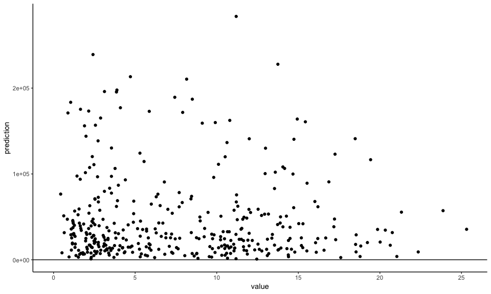

```r
plot(pred.gp.p2.mod)
```

Fitted vs. predicted separated by time:

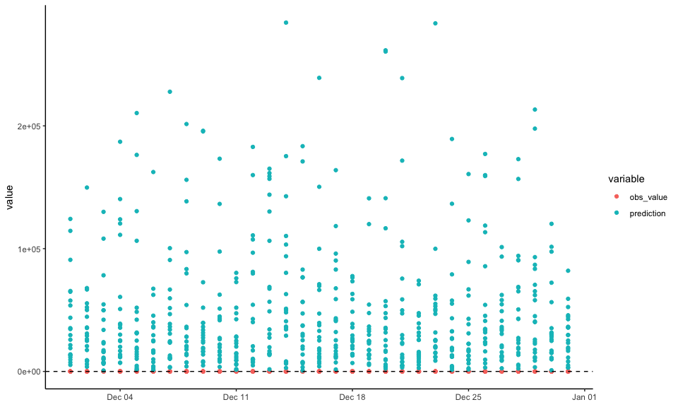

```r
plot(pred.gp.p2.mod, time_dimension = TRUE)
```

# Various Bayesian Models

There are more Models besides the Gaussian Process. For example, the autoregressive Gaussian Process:

```r
priors.ar <- spT.priors(model = "AR",
                        inv.var.prior = Gamm(a = 2, b = 1),
                        beta.prior = Norm(0, 10^4),
                        rho.prior=Norm(0,10^10))
model.ar.p2 <- fit_sp_model(data = data,
                            formula = formula,
                            model = 'AR',
                            priors = priors.ar,
                            cov.fnc = cov.fnc,
                            report = report,
                            training_set = training_set,
                            scale.transform = scale.transform,
                            spatial.decay = spatial.decay)
```

```
#>
#>  Output: AR models
#> ---------------------------------------------------------------
#>  Sampled: 1000 of 5000, 20.00%.
#>  Batch Acceptance Rate (phi): 35.74%
#>  Checking Parameters:
#>    phi: 8.0592, rho: 0.5375, sig2eps: 0.1830, sig2eta: 0.2867
#>    beta[1]: 2.0522   beta[2]: 0.0020   beta[3]: -0.0238   beta[4]: -0.0317   beta[5]: -0.0437   beta[6]: 0.0015   beta[7]: -0.0354
#> ---------------------------------------------------------------
#> ---------------------------------------------------------------
#>  Sampled: 2000 of 5000, 40.00%.
#>  Batch Acceptance Rate (phi): 35.82%
#>  Checking Parameters:
#>    phi: 6.8876, rho: 0.5238, sig2eps: 0.1781, sig2eta: 0.2841
#>    beta[1]: 1.9425   beta[2]: 0.0037   beta[3]: -0.0291   beta[4]: -0.0200   beta[5]: -0.0459   beta[6]: 0.0212   beta[7]: -0.0279
#> ---------------------------------------------------------------
#> ---------------------------------------------------------------
#>  Sampled: 3000 of 5000, 60.00%.
#>  Batch Acceptance Rate (phi): 36.78%
#>  Checking Parameters:
#>    phi: 10.2228, rho: 0.5384, sig2eps: 0.1922, sig2eta: 0.2881
#>    beta[1]: 2.0797   beta[2]: 0.0027   beta[3]: -0.0156   beta[4]: -0.0153   beta[5]: -0.0465   beta[6]: 0.0427   beta[7]: -0.0519
#> ---------------------------------------------------------------
#> ---------------------------------------------------------------
#>  Sampled: 4000 of 5000, 80.00%.
#>  Batch Acceptance Rate (phi): 36.53%
#>  Checking Parameters:
#>    phi: 8.3423, rho: 0.5383, sig2eps: 0.1871, sig2eta: 0.2695
#>    beta[1]: 2.0640   beta[2]: 0.0033   beta[3]: -0.0194   beta[4]: -0.0238   beta[5]: -0.0418   beta[6]: 0.0411   beta[7]: -0.0853
#> ---------------------------------------------------------------
#> ---------------------------------------------------------------
#>  Sampled: 5000 of 5000, 100.00%.
#>  Batch Acceptance Rate (phi): 36.77%
#>  Checking Parameters:
#>    phi: 10.3588, rho: 0.5044, sig2eps: 0.2042, sig2eta: 0.2820
#>    beta[1]: 2.1802   beta[2]: 0.0036   beta[3]: -0.0277   beta[4]: -0.0222   beta[5]: -0.0495   beta[6]: -0.0094   beta[7]: -0.0441
#> ---------------------------------------------------------------
#> ##
#> # nBurn =  1000 , Iterations =  5000 .
#> # Overall Acceptance Rate (phi) =  36.76 %
#> ##
#> ##
#> # Elapsed time: 34.21 Sec.
#> ##
#>
#> # Model: AR
```

```r
pred.ar.p2 <- predict(model.ar.p2, data, training_set)
```

[output not shown]

```r
evaluate_prediction(pred.ar.p2)
```

```
#>   RMSE  MAE  BIAS Coverage   R2
#> 1 4.18 3.16 -0.52     0.93 0.66
```

The last model is the Gaussian Predictive Process, here we have to specify two more things: - How much knots should be used? - How should the knots be placed? Detailed options for that question are shown in 4_advanced_modelling.R

```r
priors.gpp <- spT.priors(model = "GPP", inv.var.prior = Gamm(a = 2, b = 1),
                        beta.prior = Norm(0, 10^4))
model.gpp.p2 <- fit_sp_model(data = data,
                            formula = formula,
                            model = 'GPP',
                            priors = priors.gpp,
                            cov.fnc = cov.fnc,
                            knots_count = 4,
                            report = report,
                            training_set = training_set,
                            scale.transform = scale.transform,
                            spatial.decay = spatial.decay)
```

```
#>
#>  Output: GPP approximation models
#> ---------------------------------------------------------------
#>  Sampled: 1000 of 5000, 20.00%.
#>  Batch Acceptance Rate (phi): 55.96%
#>  Checking Parameters:
#>    phi: 0.2028, rho: 0.8375, sig2eps: 0.8390, sig2eta: 8.5643
#>    beta[1]: 8.8213   beta[2]: 0.0092   beta[3]: -0.0507   beta[4]: -0.0898   beta[5]: -0.1025   beta[6]: 0.1032   beta[7]: -0.1729
#> ---------------------------------------------------------------
#> ---------------------------------------------------------------
#>  Sampled: 2000 of 5000, 40.00%.
#>  Batch Acceptance Rate (phi): 41.52%
#>  Checking Parameters:
#>    phi: 0.0051, rho: 0.2814, sig2eps: 0.4481, sig2eta: 4.4292
#>    beta[1]: 0.2948   beta[2]: 0.0049   beta[3]: -0.0692   beta[4]: -0.0391   beta[5]: -0.0908   beta[6]: 0.0164   beta[7]: -0.0119
#> ---------------------------------------------------------------
#> ---------------------------------------------------------------
#>  Sampled: 3000 of 5000, 60.00%.
#>  Batch Acceptance Rate (phi): 33.58%
#>  Checking Parameters:
#>    phi: 0.0098, rho: 0.3642, sig2eps: 0.5073, sig2eta: 0.2891
#>    beta[1]: 3.1517   beta[2]: 0.0073   beta[3]: -0.0539   beta[4]: -0.0577   beta[5]: -0.0863   beta[6]: 0.0235   beta[7]: -0.1963
#> ---------------------------------------------------------------
#> ---------------------------------------------------------------
#>  Sampled: 4000 of 5000, 80.00%.
#>  Batch Acceptance Rate (phi): 29.46%
#>  Checking Parameters:
#>    phi: 0.0002, rho: 0.1826, sig2eps: 0.3965, sig2eta: 68.9681
#>    beta[1]: -8.8680   beta[2]: 0.0051   beta[3]: -0.0531   beta[4]: -0.0508   beta[5]: -0.0850   beta[6]: 0.0189   beta[7]: -0.0379
#> ---------------------------------------------------------------
#> ---------------------------------------------------------------
#>  Sampled: 5000 of 5000, 100.00%.
#>  Batch Acceptance Rate (phi): 26.95%
#>  Checking Parameters:
#>    phi: 0.0004, rho: 0.3181, sig2eps: 0.4748, sig2eta: 49.2391
#>    beta[1]: -6.9318   beta[2]: 0.0072   beta[3]: -0.0502   beta[4]: -0.0505   beta[5]: -0.0939   beta[6]: 0.0947   beta[7]: -0.1916
#> ---------------------------------------------------------------
#> ##
#> # nBurn =  1000 . Iterations =  5000 .
#> # Acceptance rate: (phi) =  26.94 %
#> ##
#> ##
#> # Elapsed time: 3.07 Sec.
#> ##
#>
#> # Model: GPP
```

```r
pred.gpp.p2 <- predict(model.gpp.p2, data, training_set)
```

[output not shown]

```r
evaluate_prediction(pred.gpp.p2)
```

```
#>   RMSE  MAE  BIAS Coverage   R2
#> 1  4.3 3.32 -0.36     0.97 0.62
```

# Compair the models

```r
evaluate_prediction_table(list('pred.gp.p2' = pred.gp.p2,
                               'pred.gp.p2.mod' = pred.gp.p2.mod,
                               'pred.ar.p2' = pred.ar.p2,
                               'pred.gpp.p2' = pred.gpp.p2))
```

```
#>             model     RMSE      MAE     BIAS Coverage    R2
#> 1:     pred.gp.p2     4.75     3.62    -0.67     0.99  0.51
#> 2: pred.gp.p2.mod 66711.52 45565.59 45565.59     1.00 -0.03
#> 3:     pred.ar.p2     4.18     3.16    -0.52     0.93  0.66
#> 4:    pred.gpp.p2     4.30     3.32    -0.36     0.97  0.62
```

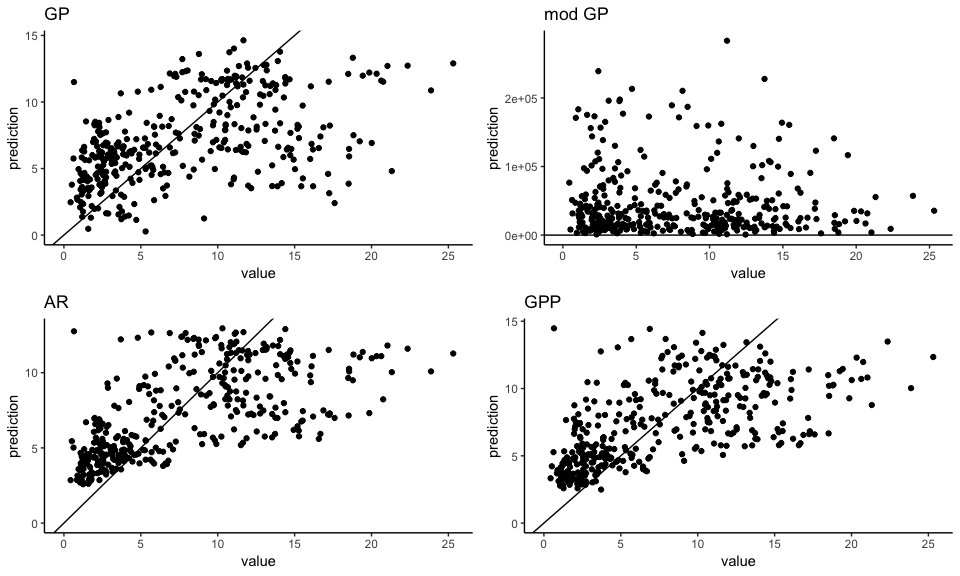

```r
gridExtra::grid.arrange(grobs = list(
  plot(pred.gp.p2) + ggtitle('GP'),
  plot(pred.gp.p2.mod) + ggtitle('mod GP'),
  plot(pred.ar.p2) + ggtitle('AR'),
  plot(pred.gpp.p2) + ggtitle('GPP')
))


```